# HW3: Almond Profit and Informal Sensitivity Analysis

Katheryn Moya & Nick McManus

4/27/2023

```r
knitr::opts_chunk$set(echo = TRUE, warning = F, message = F)

library(tidyverse)
library(here)
library(purrr)
```

# Read in and wrangle climate data

First we’ll read in our `clim.txt` data file, which provides daily precipitation as well as minimum and maximum temperatures. Next, we’ll create a data subset with the total precipitation and absolute minimum and maximum temperatures for each month. Then, we’ll form two subsets for use in the almond yield function: one with minimum February temperatures and another with the total January precipitation.

```r
### Read in data
clim_df <- read_table("clim.txt") %>%
  ## remove quotes in names
  janitor::clean_names()


### Find the absolute tmin and tmax and summed precip
clim_months <- clim_df %>%
  group_by(month, year) %>%
  summarize(tmax_max = max(tmax_c),
            tmin_min = min(tmin_c),
            precip_sum = sum(precip))


### Filter for Feb Tmin
tmin_feb <- clim_months %>%
  filter(month ==2) %>%
  ungroup() %>%
  select(year, tmin_min)

### Filter for Jan precip
precip_jan <- clim_months %>%
  filter(month == 1) %>%
  ungroup() %>%
  select(year, precip_sum)
```

# Sensitivity Analysis

We’ll perform the sensitivity analysis using outputs from the almond yield function. This function outputs the profit based on yield anomaly for each year within the time series.

```r
### Read in function
source(here("R/almond_yield_profit.R"))
```

## Generate samples

For this analysis, we’re testing for the uncertainties surrounding the `tcoeff1` and `pcoeff2` parameters – which affect almond yield – as well as the price per ton/acre (`price_ton`) for almonds. The informal sensitivity analysis for the `tcoeff1` parameter includes the following assumptions:

- Default value of the parameter is -0.015
- Uncertainty of $$20% for parameter value
- Uniform distribution since we do not know anything about variation

For `pcoeff2`, the following assumptions were used to generate a sample of values: * Default value of parameter is 0.0043 * Uncertainty of $$20% for parameter value * Uniform distribution since we do not know anything about variation

```r
## Number of samples
nsamples = 300
## Percent deviation from baseline
dev = 0.2


### Generate tcoeff1 samples
tcoeff1_base = -0.015
tcoeff1 <- runif(min = tcoeff1_base + tcoeff1_base*dev,
                        max = tcoeff1_base - tcoeff1_base*dev,
                        n = nsamples)

### Generate pcoeff2 sample
pcoeff2 <- 0.0043
pcoeff2 <- runif(min = pcoeff2 - pcoeff2*dev,
                 max = pcoeff2 + pcoeff2*dev,
                 n = nsamples)

### Generate price samples
price_ton <- rnorm(mean = 3520, sd = 100, n = nsamples)



### bind samples together in one df
params <- cbind.data.frame(tcoeff1, pcoeff2, price_ton)
```

## Run function with `purrr::pmap()`

```r
### run with pmap
results <- params %>% pmap(almond_yield_profit,
                           tmin = tmin_feb$tmin_min,
                           precip = precip_jan$precip_sum,
                           year = tmin_feb$year)

### View head of results and make sure length = 300
# results[[1]]
# length(results)

### Extract results from list into df
profit <- map_df(results, `[`, c("year", "profit"))


# profit_subset <- profit %>%
#   filter(!year %in% c(1995, 1997, 2001, 2005, 2008, 2010))

### Exploratory stuff to see which parameters have biggest effect

# ### Bind results to the input parameter values
# profit <- cbind.data.frame(profit, params)
#
#
# p1 = ggplot(yield_profit, aes(x = tcoeff1, y = mean_profit, col=pcoeff2))+
#   geom_point(cex=2)+
#   labs(y="Profit (USD/TON/ACRE)", x="tcoeff1")
# p2 = ggplot(yield_profit, aes(x = tcoeff2, y = mean_profit, col=pcoeff2))+
#   geom_point(cex=2)+
#   labs(y="Profit (USD/TON/ACRE)", x="tcoeff2")
# p3 = ggplot(yield_profit, aes(x = pcoeff1, y = mean_profit, col=tcoeff1))+
#   geom_point(cex=2)+
#   labs(y="Profit (USD/TON/ACRE)", x="pcoeff1")
# p4 = ggplot(yield_profit, aes(x = pcoeff2, y = mean_profit, col=tcoeff1))+
#   geom_point(cex=2)+
#   labs(y="Profit (USD/TON/ACRE)", x="pcoeff2")
# ggarrange(p1,p2,p3, p4)
```

## Visualize results

Finally, the profit for each year are visualized to informally view the uncertainty of almond profit based on three parameters.

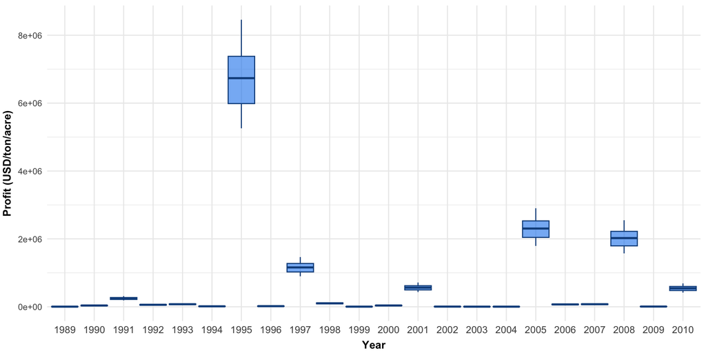

```r
ggplot(profit, aes(x = as.factor(year), y = profit, group = year)) +
  geom_boxplot(fill = 'dodgerblue2', color = 'dodgerblue4',
               alpha = 0.6, width = 0.9) +
  labs(y="Profit (USD/ton/acre)", x="Year") +
  # scale_y_log10()+
  theme_minimal() +
  theme(
    axis.title.x = element_text(face = 'bold', size = 11, vjust = -0.4),
    axis.title.y = element_text(face = 'bold', size = 11, vjust = 2),
    axis.text.x = element_text(size = 10)
  )
```